# The Instacart Online Grocery Shopping Dataset 2017

9/13/2017

#### Figure 1. Day of the Week Analysis

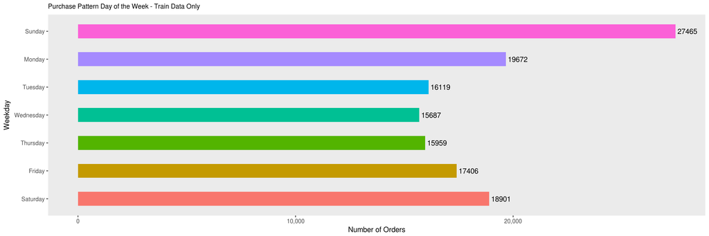

The most number of orders were placed on Sunday, followed by Monday and Saturday. As expected shopping during the weekends in much higher than the weekdays. Wednesday and Thursday has the lowest number of shopping orders.

#### Figure 2. Hour of the Day Analysis

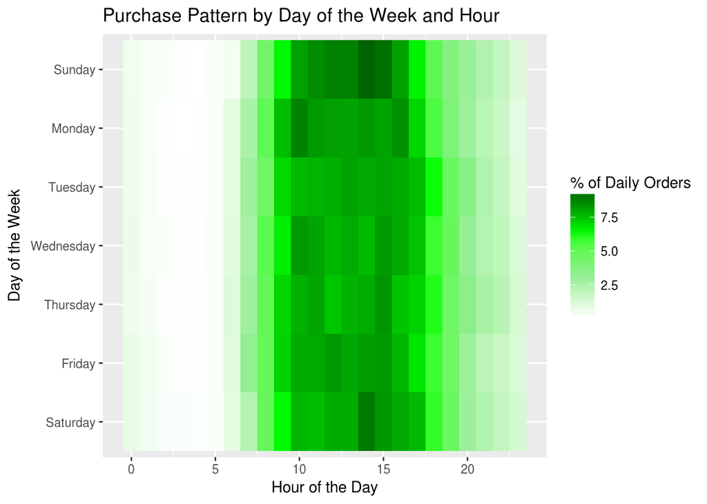

Looking at the hour of the day for online grocery shopping, late mornings to early evening seems to be the most popular time on Sunday when most of the days orders are placed. Almost 10% of the total orders on Sunday is placed around 2PM. Similar is the pattern for Saturday. For the rest of the days, the patten is mostly mixed.

#### Figure 3. Hour of the Day Analysis

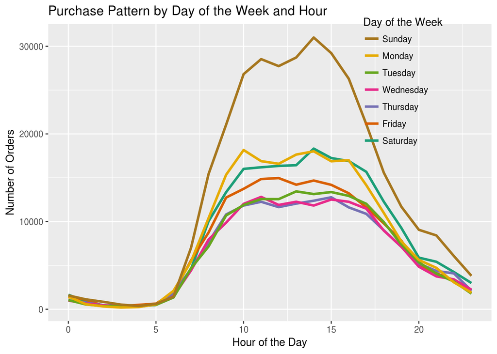

The graph reiterates the previous two graphs about the day of the week and the hour of the day analyses. Sunday stands out in the number of orders as well as the hours during which the orders are placed. For all days, the orders pick up around 6AM.

#### Figure 4. Product Department Analysis

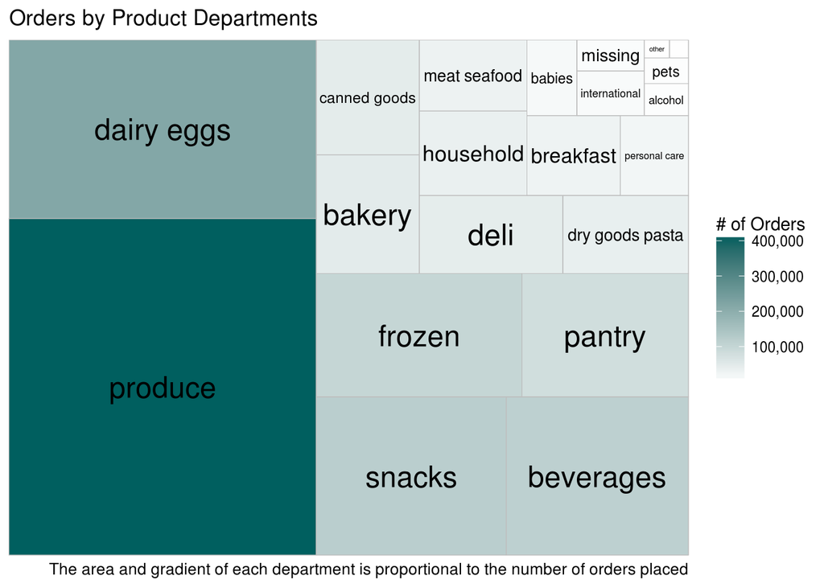

The tree map above shows the product departments with the most number of orders. *Produce* is the most ordered department followed by *dairy eggs*. This seems plausible as they are perishable goods, and people would prefer to order them frequently hence the spike in the number of times they are ordered. At the same time they may also be indicative of the food preferences of customers. There seems to be fewer orders for *meat seafood* and *bakery*.

#### Figure 5. Product Aisle Analysis

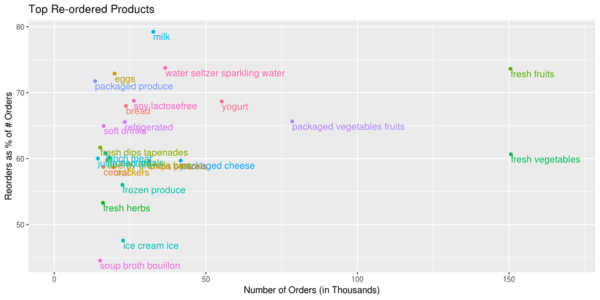

The above graph shows re-order as a percent of total orders of a product aisle. Of all the orders placed for milk, 80% of them seems to be re-orders. This chart also show the consumption preferences among customers. Other highly re-ordered products include water, eggs, produce, fresh fruits and so on.

#### Figure 6. Most Ordered Products with Word Cloud

[interactive chart not shown]

The word cloud shows the top 50 most ordered products. Fresh fruits and vegetables lead the pack.

##### References

Treemap: Installed from https://github.com/wilkox/treemapify  
Word Cloud: https://cran.r-project.org/web/packages/hunspell/vignettes/intro.html